# Machine Learning in R

Jim Gruman

2019-05-05T00:00:00+01:00

## Data Exploration

This time we will load all of the packages in tidyverse.

We can measure the spread of the features independently. For example, for the ‘price’ feature, we can get mean, min, max and range.

```r
usedcars %>% pull(price) %>% mean()
```

```
## [1] 12961.93
```

```r
usedcars %>% pull(price) %>% min()
```

```
## [1] 3800
```

```r
usedcars %>% pull(price) %>% max()
```

```
## [1] 21992
```

```r
usedcars %>% pull(price) %>% range()
```

```
## [1]  3800 21992
```

We can also get the difference of the range,…

```r
usedcars %>% pull(price) %>% range() %>% diff()
```

```
## [1] 18192
```

…and the inter-quartile range (Q3-Q1) using the IQR() function.

```r
usedcars %>% pull(price) %>% IQR()
```

```
## [1] 3909.5
```

We can also use the quantile() function to calculate the five-number summary, …

```r
usedcars %>% pull(price) %>% quantile()
```

```
##      0%     25%     50%     75%    100%
##  3800.0 10995.0 13591.5 14904.5 21992.0
```

… and the 1st and 99th percentiles for example.

```r
usedcars %>% pull(price) %>% quantile(probs = c(0.01, 0.99))
```

```
##       1%      99%
##  5428.69 20505.00
```

The var() and sd() functions give us the variance and standard deviation.

```r
usedcars %>% pull(price) %>% var()
```

```
## [1] 9749892
```

```r
usedcars %>% pull(price) %>% sd()
```

```
## [1] 3122.482
```

```r
summary(usedcars$price)
```

```
##    Min. 1st Qu.  Median    Mean 3rd Qu.    Max.
##    3800   10995   13592   12962   14904   21992
```

Notice that ‘model’, ‘color’ and ‘transmission’ are treated as string values. To get better summaries, we need to convert them to factors. Let’s also convert ‘year’ to a factor.

```r
usedcars <- mutate(usedcars, year = as.factor(year))
usedcars <- mutate(usedcars, model = as.factor(model))
usedcars <- mutate(usedcars, color = as.factor(color))
usedcars <- mutate(usedcars, transmission = as.factor(transmission))
```

Notice the differences in the presentation of the factors in the summary

```r
summary(usedcars)
```

```
##       year    model        price          mileage           color
##  2010   :49   SE :78   Min.   : 3800   Min.   :  4867   Black  :35
##  2009   :42   SEL:23   1st Qu.:10995   1st Qu.: 27200   Silver :32
##  2011   :16   SES:49   Median :13592   Median : 36385   Red    :25
##  2008   :14            Mean   :12962   Mean   : 44261   Blue   :17
##  2007   :11            3rd Qu.:14904   3rd Qu.: 55125   Gray   :16
##  2006   : 6            Max.   :21992   Max.   :151479   White  :16
##  (Other):12                                             (Other): 9
##  transmission
##  AUTO  :128
##  MANUAL: 22
##
##
##
##
##
```

To see the full data distribution for a feature, we use the table() function.

```r
usedcars %>% pull(year) %>% table()
```

```
## .
## 2000 2001 2002 2003 2004 2005 2006 2007 2008 2009 2010 2011 2012
##    3    1    1    1    3    2    6   11   14   42   49   16    1
```

```r
usedcars %>% pull(color) %>% table()
```

```
## .
##  Black   Blue   Gold   Gray  Green    Red Silver  White Yellow
##     35     17      1     16      5     25     32     16      3
```

We can also compute the distribution proportions (rounded to 2 decimal places).

```r
usedcars %>% pull(model) %>% table()
```

```
## .
##  SE SEL SES
##  78  23  49
```

```r
usedcars %>% pull(model) %>% table() %>% prop.table() %>% round(digits=4) * 100
```

```
## .
##    SE   SEL   SES
## 52.00 15.33 32.67
```

Let’s do some visual exploration against our data.

Create a scatterplot of price vs. mileage.

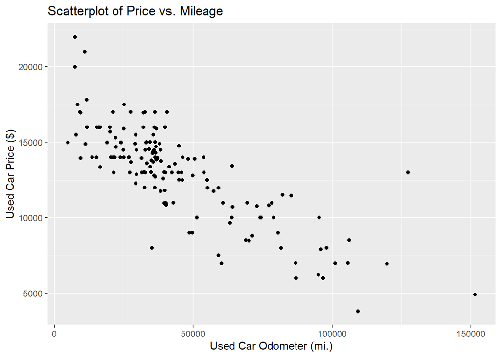

```r
usedcars %>%
ggplot() +
  geom_point(mapping = aes(x = mileage, y = price)) +
  labs(title = "Scatterplot of Price vs. Mileage", x = "Used Car Odometer (mi.)", y = "Used Car Price ($)")
```

What can we infer from the scatterplot?

What if we tried to group our plot by transmission? Do we learn anything new?

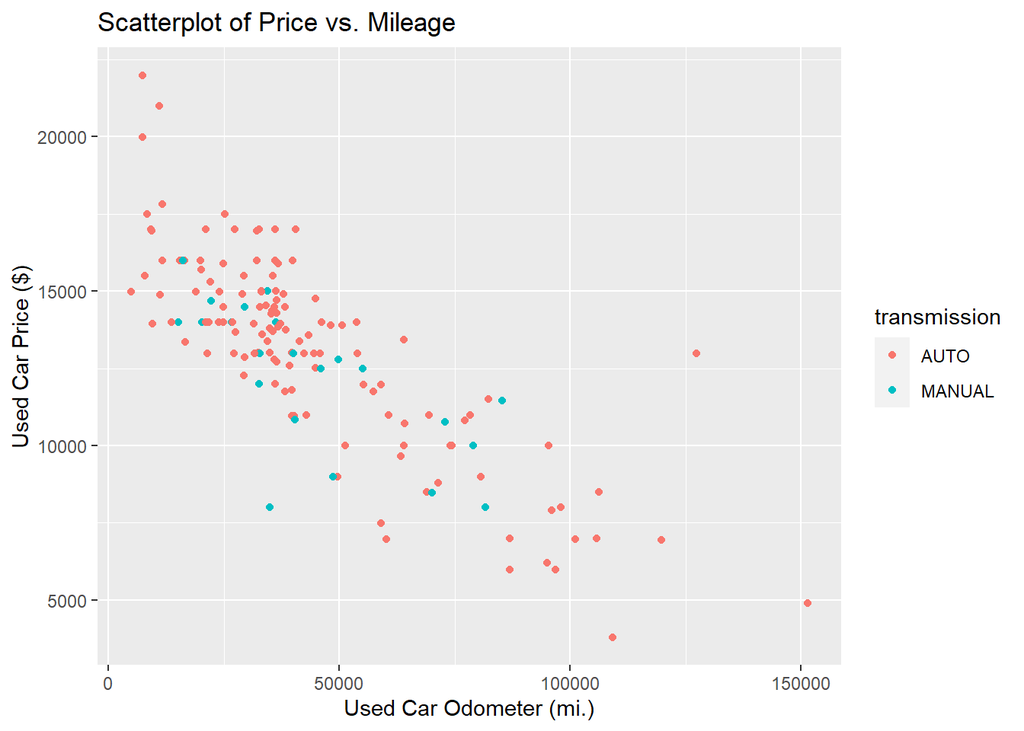

```r
usedcars %>%
  ggplot() +
  geom_point(mapping = aes(x = mileage, y = price, color = transmission)) +
  labs(title = "Scatterplot of Price vs. Mileage", x = "Used Car Odometer (mi.)", y = "Used Car Price ($)")
```

What about grouping by model?

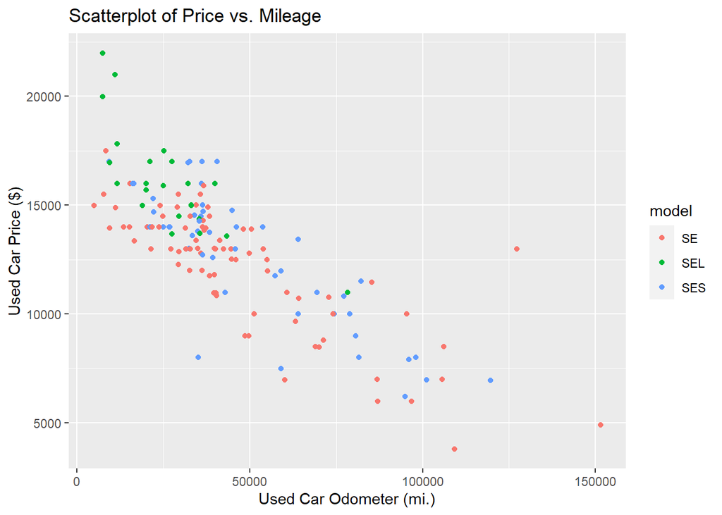

```r
usedcars %>%
  ggplot() +
  geom_point(mapping = aes(x = mileage, y = price, color = model)) +
  labs(title = "Scatterplot of Price vs. Mileage", x = "Used Car Odometer (mi.)", y = "Used Car Price ($)")
```

And when you group by year, what do we see?

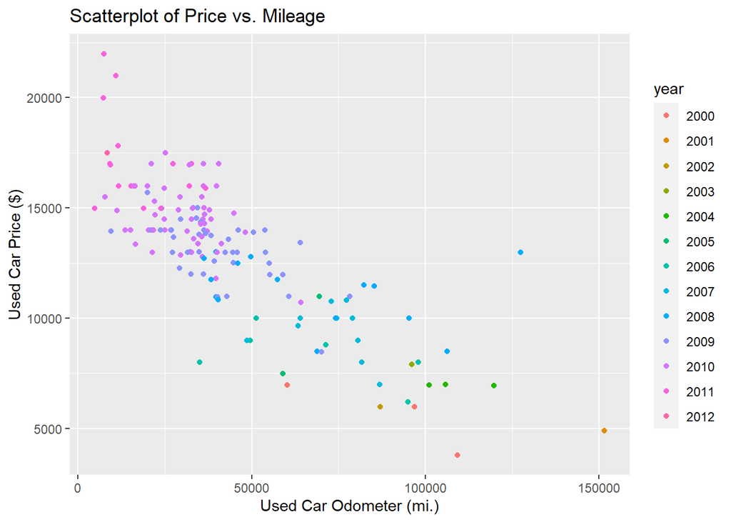

```r
usedcars %>%
  ggplot() +
  geom_point(mapping = aes(x = mileage, y = price, color = year)) +
  labs(title = "Scatterplot of Price vs. Mileage", x = "Used Car Odometer (mi.)", y = "Used Car Price ($)")
```

Using a box plot to show price by year reveals the expected.

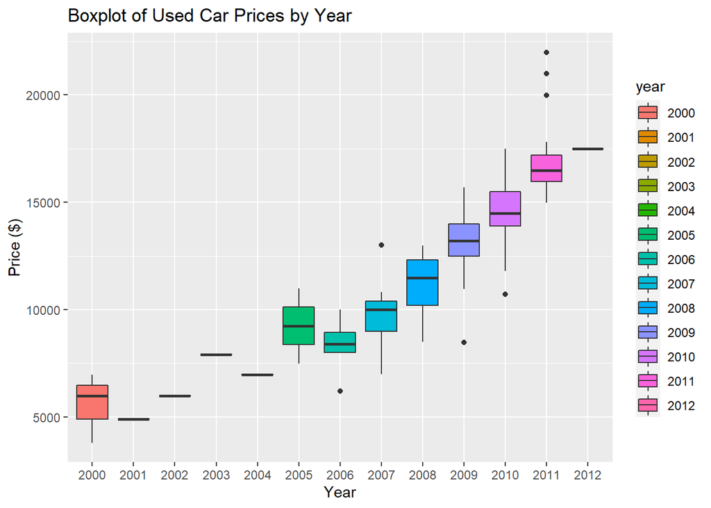

```r
usedcars %>%
  ggplot() +
  geom_boxplot(mapping = aes(x = year, y = price, fill = year)) +
  labs(title = "Boxplot of Used Car Prices by Year", x = "Year", y = "Price ($)")
```

What does the boxplot of price by model type tell us?

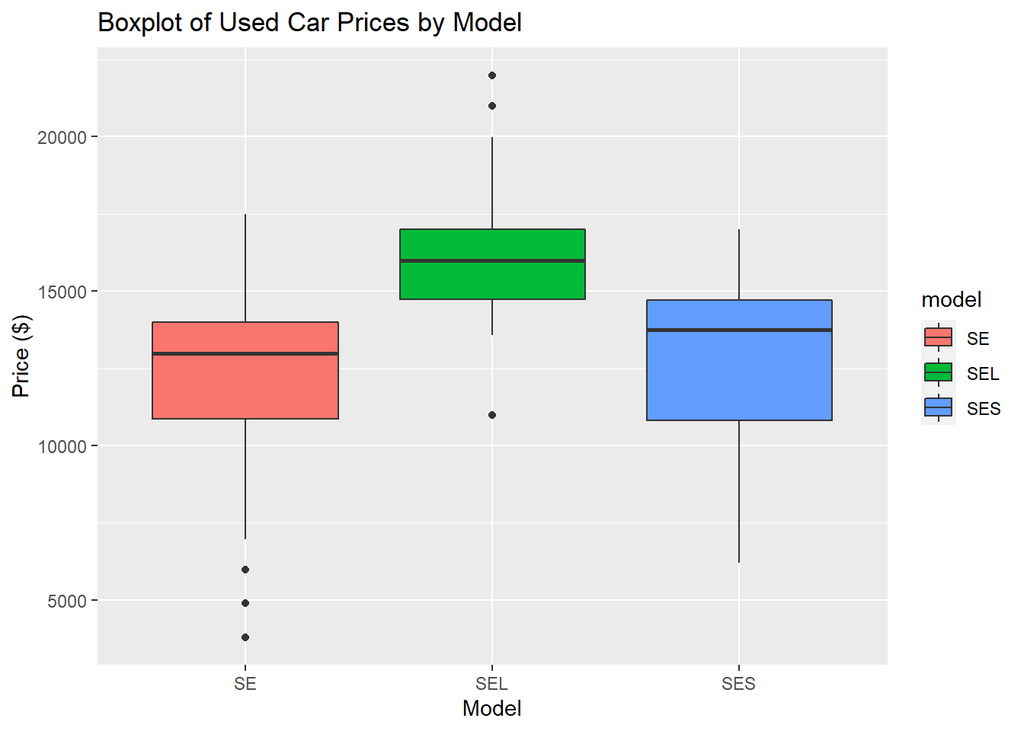

```r
usedcars %>%
  ggplot() +
  geom_boxplot(mapping = aes(x = model, y = price, fill = model)) +
  labs(title = "Boxplot of Used Car Prices by Model", x = "Model", y = "Price ($)")
```